# Statistical Inference Assignment Part2

Sharath G

```r
    library(knitr)
    library(ggplot2)
    opts_chunk$set(echo=TRUE, warning=FALSE, message=FALSE)
```

Load and run summary statistics on the ToothGrowth dataset. We aim to understand whether increasing dosage or diets impact tooth growth.

```r
library(datasets)
head(ToothGrowth)
```

```
##    len supp dose
## 1  4.2   VC  0.5
## 2 11.5   VC  0.5
## 3  7.3   VC  0.5
## 4  5.8   VC  0.5
## 5  6.4   VC  0.5
## 6 10.0   VC  0.5
```

```r
str(ToothGrowth)
```

```
## 'data.frame':    60 obs. of  3 variables:
##  $ len : num  4.2 11.5 7.3 5.8 6.4 10 11.2 11.2 5.2 7 ...
##  $ supp: Factor w/ 2 levels "OJ","VC": 2 2 2 2 2 2 2 2 2 2 ...
##  $ dose: num  0.5 0.5 0.5 0.5 0.5 0.5 0.5 0.5 0.5 0.5 ...
```

```r
ToothGrowth$dose <- factor(ToothGrowth$dose)
ToothGrowth$supp <- factor(ToothGrowth$supp)
```

First, we perform exploratory analysis of the data to establish a link between our explanatory variables and tooth growth. Looking at the data below, it appears that OJ has a greater effect on tooth growth than VC. In addition, it appears as the dosage increases, tooth growth increases.

```r
summary(ToothGrowth)
```

```
##       len        supp     dose
##  Min.   : 4.20   OJ:30   0.5:20
##  1st Qu.:13.07   VC:30   1  :20
##  Median :19.25           2  :20
##  Mean   :18.81
##  3rd Qu.:25.27
##  Max.   :33.90
```

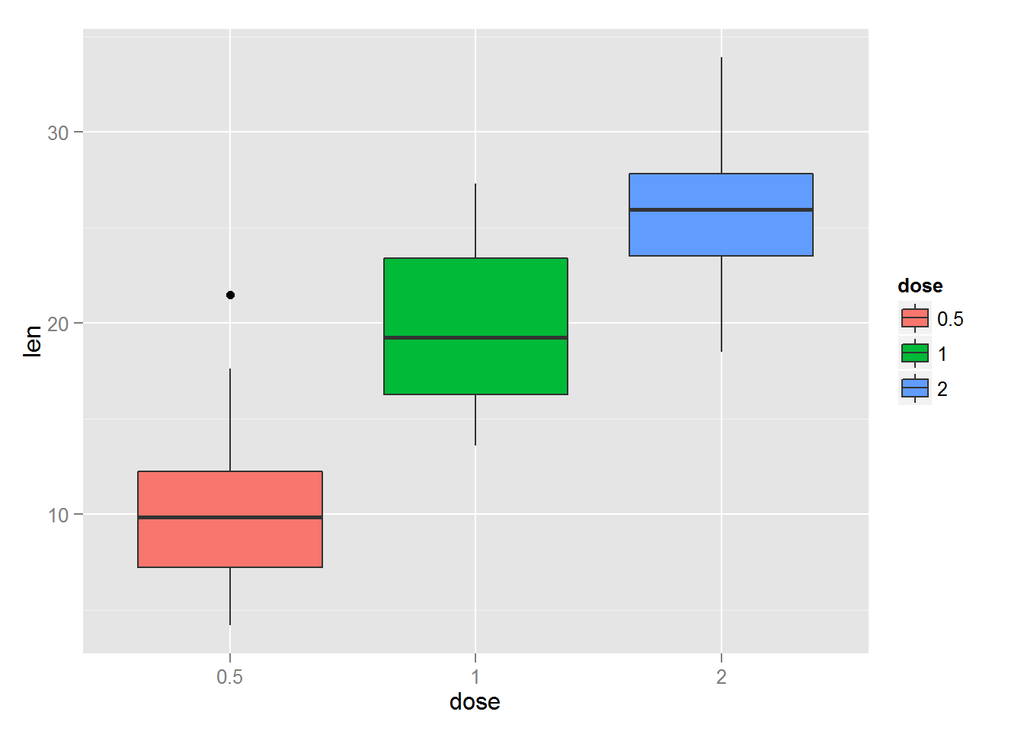

```r
library(ggplot2)
ggplot(data=ToothGrowth, aes(x=dose, y=len) ) + geom_boxplot(aes(fill=dose))
```

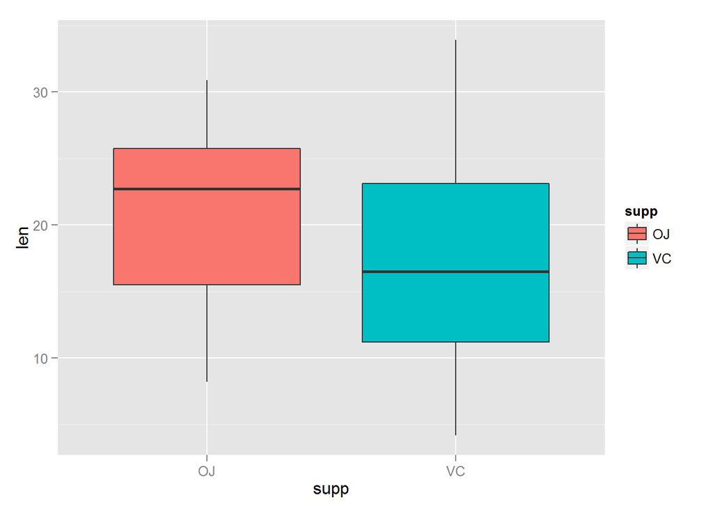

```r
ggplot(data=ToothGrowth, aes(x=supp, y=len) ) + geom_boxplot(aes(fill=supp))
```

Now, we perform inferential analysis on the data to understand if these relationships hold up statitically.

First, let’s look at the effect of diet on tooth growth. Taking the difference between sample means, we see that the 95% confidence interval includes 0. In addition, the p value is 6% which indicates that there is no significant difference in impacts between OJ and VC.

```r
t.test(len ~ supp, data = ToothGrowth, paired = FALSE)
```

```
##
##  Welch Two Sample t-test
##
## data:  len by supp
## t = 1.9153, df = 55.309, p-value = 0.06063
## alternative hypothesis: true difference in means is not equal to 0
## 95 percent confidence interval:
##  -0.1710156  7.5710156
## sample estimates:
## mean in group OJ mean in group VC
##         20.66333         16.96333
```

Now, let’s look at the effect of dosage on tooth growth. Looking at the p values and the confidence intervals we can conclude that increasing dosage increases tooth growth.

```r
dose_0.5_1 <- ToothGrowth[ToothGrowth$dose %in% c(0.5, 1.0),]
dose_1.0_2 <- ToothGrowth[ToothGrowth$dose %in% c(2.0, 1.0),]
dose_0.5_2 <- ToothGrowth[ToothGrowth$dose %in% c(0.5, 2.0),]
t.test (len ~ dose, data = dose_0.5_1, paired= FALSE)
```

```
##
##  Welch Two Sample t-test
##
## data:  len by dose
## t = -6.4766, df = 37.986, p-value = 1.268e-07
## alternative hypothesis: true difference in means is not equal to 0
## 95 percent confidence interval:
##  -11.983781  -6.276219
## sample estimates:
## mean in group 0.5   mean in group 1
##            10.605            19.735
```

```r
t.test (len ~ dose, data = dose_1.0_2, paired= FALSE)
```

```
##
##  Welch Two Sample t-test
##
## data:  len by dose
## t = -4.9005, df = 37.101, p-value = 1.906e-05
## alternative hypothesis: true difference in means is not equal to 0
## 95 percent confidence interval:
##  -8.996481 -3.733519
## sample estimates:
## mean in group 1 mean in group 2
##          19.735          26.100
```

```r
t.test (len ~ dose, data = dose_0.5_2, paired= FALSE)
```

```
##
##  Welch Two Sample t-test
##
## data:  len by dose
## t = -11.799, df = 36.883, p-value = 4.398e-14
## alternative hypothesis: true difference in means is not equal to 0
## 95 percent confidence interval:
##  -18.15617 -12.83383
## sample estimates:
## mean in group 0.5   mean in group 2
##            10.605            26.100
```

Based on the analysis we conclude that there is no significant impact of supp on tooth growth, although there is directional evidence that OJ has a stronger effect than VC. However, increasing dosage significantly increases tooth growth.